# ISHE 2027 en Bogotá

Congreso de la Sociedad Internacional de Etología Humana

Juan David Leongómez

[figure not shown]

27 de octubre de 2026

## Qué es ISHE

Sociedad científica internacional que estudia el comportamiento humano desde un marco darwiniano: la selección natural y cultural moldea la cognición, el afecto y la conducta.

- Fundada en **1972**
- **Interdisciplinaria**: psicología, antropología, biología, primatología, psiquiatría, salud pública, enfermería y etología
- Miembros de unos **26 países**
- Revista de acceso abierto *Human Ethology*

1972 Año de fundación

~26 Países de origen de sus miembros

~130 Participantes esperados en Bogotá

## Dónde se ha hecho antes

Congresos internacionales

- [**2026**](https://ishe.org/wp-content/uploads/2026/06/BoA_ISHE26_Final_DIGITAL.pdf) Les Eyzies, Francia
- [**2024**](https://ishe.org/wp-content/uploads/2024/11/BoA_2024_v07_km.pdf) Humboldt, EE. UU.
- [**2022**](https://ishe.org/wp-content/uploads/2022/08/HE_2022_37_suppl.pdf) Würzburg, Alemania
- [**2021**](https://ishe.org/wp-content/uploads/2021/09/HE_Abstracts_2021.pdf) En línea e internacional
- [**2018**](https://ishe.org/wp-content/uploads/2018/09/Program-ISHE-2018.pdf) Santiago, Chile
- [**2016**](https://ishe.org/wp-content/uploads/2015/03/Stirling2016.pdf) Stirling, Escocia
- [**2014**](https://ishe.org/wp-content/uploads/2015/03/Belem2014.pdf) Belém, Brasil
- [**2012**](https://ishe.org/wp-content/uploads/2015/03/PROGRAMM_ISHE2012.pdf) Viena, Austria
- [**2010**](https://ishe.org/wp-content/uploads/2015/03/Madison2010.pdf) Madison, EE. UU.
- [**2008**](https://ishe.org/wp-content/uploads/2015/03/Bologna2008.pdf) Bolonia, Italia
- [**2006**](https://ishe.org/wp-content/uploads/2015/03/Detroit2006.pdf) Detroit, EE. UU.
- [**2004**](https://ishe.org/wp-content/uploads/2015/03/Ghent2004.pdf) Gante, Bélgica
- [**2002**](https://ishe.org/wp-content/uploads/2015/03/Montreal2002.pdf) Montreal, Canadá
- [**2000**](https://ishe.org/wp-content/uploads/2015/03/Salamanca2000.pdf) Salamanca, España
- [**1998**](https://ishe.org/wp-content/uploads/2015/03/Burnaby1998.pdf) Burnaby, Canadá
- [**1996**](https://ishe.org/wp-content/uploads/2015/03/Vienna-1996.pdf) Viena, Austria
- [**1994**](https://ishe.org/wp-content/uploads/2015/03/Toronto-1994.pdf) Toronto, Canadá

Summer Institutes

- [**2025**](https://ishe.org/wp-content/uploads/2025/07/BoA_2025.pdf) Chile y Austria
- [**2023**](https://ishe.org/wp-content/uploads/2023/07/BoA_v06_km.pdf) Detroit, České Budějovice y Recife
- [**2019**](https://ishe.org/wp-content/uploads/2019/09/2019-ISHE-SI-programme.pdf) Zadar, Croacia
- [**2017**](https://ishe.org/wp-content/uploads/2016/05/ISHE2017-Programme.pdf) Boise, EE. UU.
- [**2015**](https://ishe.org/wp-content/uploads/2015/03/athens2015.pdf) Atenas, Grecia
- [**2013**](https://ishe.org/wp-content/uploads/2015/03/AnnArbor2013.pdf) Ann Arbor, EE. UU.
- [**2011**](https://ishe.org/wp-content/uploads/2015/03/programme_final.pdf) Praga, República Checa
- [**2009**](https://ishe.org/wp-content/uploads/2015/03/maine2009.pdf) Maine, EE. UU.
- [**2007**](https://ishe.org/wp-content/uploads/2015/03/andechs2007.pdf) Andechs, Alemania

[interactive chart not shown]

## Dónde se ha hecho antes

[interactive chart not shown]

## Cómo llegó ISHE a Bogotá

2018 Primera propuesta de Bogotá como sede del congreso de ISHE

Finales de 2019 ISHE acepta tentativamente el Summer Institute 2021 en Bogotá, con apoyo de varios trustees. La pandemia lo cancela

Nueva candidatura Nuevo pitch pensado para un Summer Institute: diversidad biológica y cultural de Bogotá (la música como ejemplo), precios, gastronomía y conexiones aéreas

2027 ISHE decide unir el congreso y el Summer Institute, y pide a Bogotá inaugurar el nuevo formato

[figure not shown]

**Propuesta completa:** jdleongomez.github.io/Presentation-ISHE-2027/ishe2027.html

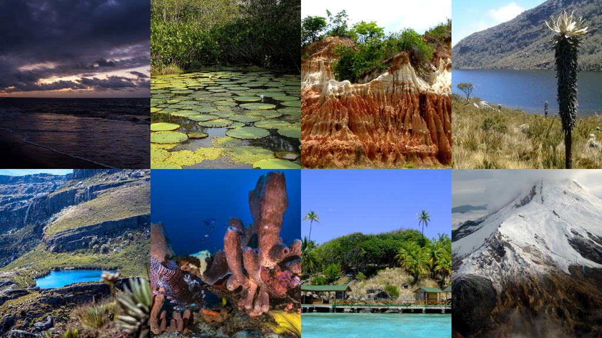

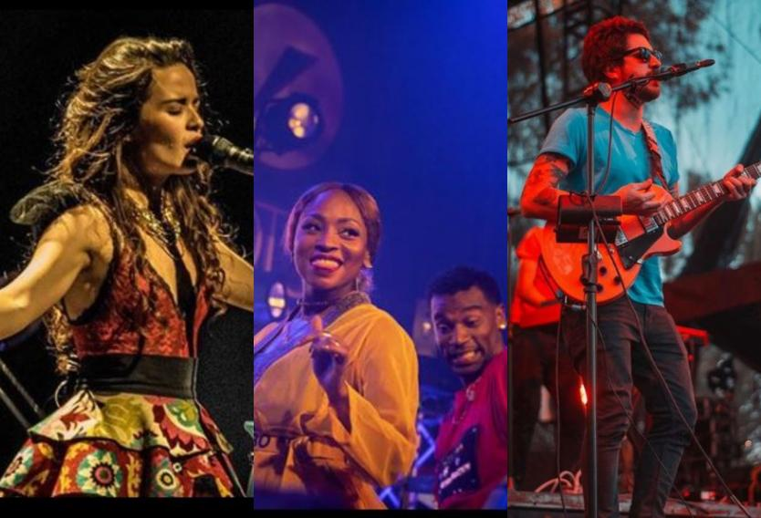

[figure not shown]

**Colombian music map:** jdleongomez.github.io/Colombian_music_map/

Bogotá inaugura el nuevo formato de ISHE

Un solo evento anual que une los talleres de posgrado y el congreso

## Por qué es importante

- **Primera vez en Colombia** y tercer país latinoamericano en acoger a ISHE (tras Brasil y Chile)
- Programa con enfoque **transcultural** y al menos una plenaria de un investigador colombiano
- **Anfitriones**:

[figure not shown]

[figure not shown]

[figure not shown]

## Plan del congreso: 5 a 9 de julio de 2027

Lun 5 Talleres para estudiantes de posgrado (festivo en Colombia)

Mar 6 Sesiones científicas y plenarias. Cóctel de bienvenida

Mié 7 Sesiones y **sesión de pósters** por la tarde

Jue 8 Sesiones hasta el mediodía. Tarde de recorrido por Bogotá (Museo del Oro, Plaza de Bolívar, Monserrate)

Vie 9 Sesión final y cena de clausura

- **130 participantes**, en un hotel de Chicó Norte (en negociación)
- Cinco plenarias (por confirmar), con comité científico internacional
- **Febrero de 2027:** inscripciones y convocatoria de resúmenes. **Abril:** cierre de resúmenes
- Viaje opcional a Cartagena y Tayrona al terminar, pagado por cada participante

## Un congreso sin ánimo de lucro

€107.000 Gasto estimado (≈ COP 400 millones)

€11.750 Ingreso previsto por inscripciones

€95.500 Cubiertos por ISHE (≈ COP 356 millones)

11%

89% lo pone ISHE

**ISHE**  
fondos de la sociedad

→

**Proveedores**  
hotel, catering, buses, guías

**Universidad El Bosque**  
ningún dinero pasa por la Universidad

## ISHE invierte en sus estudiantes

- **66 de 130** participantes con inscripción gratuita (oficiales, plenaristas y estudiantes que presentan como primeros autores*)
- **46 estudiantes alojados** por ISHE durante 5 noches: ≈ €13.400 (≈ COP 50 millones), un octavo del presupuesto total
- **Taller de posgrado** el lunes, antes del congreso
- **Premios** a los mejores pósters

**Inscripción temprana**

|  | Socio ISHE | No socio |
| --- | --- | --- |
| Estudiante | €100 | €150 |
| Investigador | €200 | €320 |

## Participar en ISHE ya ha dado resultados

2016 Stirling (congreso)

2018 Santiago (congreso)

2019 Zadar (Summer Institute)

2023 Recife (Summer Institute, invitado por ISHE)

2025 Valparaíso (Summer Institute, invitado por ISHE)

11+ Craig Roberts, trustee y expresidente de ISHE

8+ Jan Havlíček, presidente de ISHE

6+ Jaroslava Varella Valentova, vicepresidenta de ISHE

4+ Ana María Fernández, secretaria de ISHE

**Participar en ISHE se convirtió en una red de colaboración con quienes hoy la dirigen. Ser sede multiplica esa oportunidad para estudiantes y profesores de la Universidad.**

## Resultados esperados

Científicos Colaboraciones y proyectos con unos 130 investigadores internacionales. Contactos para profesores y estudiantes de varias facultades.

Visibilidad La Universidad como anfitriona en el programa, el libro de resúmenes, la web, las credenciales y los materiales del congreso. Los asistentes conocen el campus en la sesión de pósters, con difusión en los canales de ISHE y de la Universidad

Redes Invitaciones futuras, posibles intercambios y presencia de la Universidad en la investigación evolutiva de América Latina. LAAHBES, iniciativa latinoamericana liderada en su mayoría por miembros de ISHE, consolidó su plan en los encuentros de ISHE

## Qué solicitamos a la Universidad

Sesión de pósters en la Universidad Miércoles 7 de julio de 2027, por la tarde: espacio, montaje, cóctel y, si es posible, buses. Detalle en la siguiente diapositiva.

Aval institucional Aval del Consejo de Investigaciones y carta de apoyo de la Vicerrectoría.

Comunicaciones y diseño Apoyo del equipo de diseño en la imagen del congreso y difusión en los canales institucionales.

Voluntarios Estudiantes de la Universidad como apoyo del comité local (camisetas y refrigerios previstos en el presupuesto de ISHE).

## Sesión de pósters: miércoles 7 de julio, tarde

Probablemente unos **30 a 50 pósters**, unos **130 asistentes**.

Importante

**Auditorio principal** y **montaje**: paneles o caballetes para pósters en formato A0 vertical (84 × 119 cm, por confirmar con el comité científico)

Deseable

**Vino y cóctel** durante la sesión. Referencia: cotización del hotel de COP 34.000 por persona (≈ COP 4,4 millones para 130 personas)

Increíble

**Buses** hotel-Universidad, ida y vuelta: ~4 buses

## Próximos pasos

- **Noviembre de 2026:** respuesta sobre la sesión de pósters; contrato con el hotel
- **Noviembre-diciembre:** presupuesto final aprobado por ISHE
- **Febrero de 2027:** abren inscripciones y convocatoria de resúmenes
- **5-9 de julio de 2027:** congreso en Bogotá

[figure not shown]

**Sitio web del congreso**

https://2027.ishe.org/

Juan David Leongómez  
Universidad El Bosque